# Differences in care for patients experiencing left vs. right hemisphere ICH

Author

Nikhil Patel, MD

**Research question**

Do patients presenting with left hemispheric ICH receive less aggressive care (as measured by rates of neurosurgery, ventriculostomy, tracheostomy, PEG, and early withdrawal of life-sustaining therapies) as compared to those with right hemispheric ICH?

```r
library(targets)
library(skimr)
library(dplyr)
library(gt)
library(gtsummary)
library(tibble)
library(ggplot2)
library(ggdist)
library(gghalves)
library(ggdag)
library(scales)
library(dagitty)
library(marginaleffects)
library(modelsummary)

# theme customization
theme_set(theme_minimal(base_family = "Figtree"))

theme_set(
  theme_dag(base_family = "Figtree") %+replace%
    # also add some additional styling
    theme(
      legend.position = "bottom",
      strip.text.x = element_text(margin = margin(2, 0, 2, 0, "mm"))
    )
)

status_colors <- c(exposure = "#CE4441", outcome = "#004F63", latent = "grey80")

theme_gtsummary_compact()

# load all targets objects
# tar_load_everything()
tar_load(ich_aggressive)
tar_load(table_1_aggressive)
tar_load(table_2_aggressive)
tar_load(dag_aggressive)
```

## Exploratory Data Analysis

### Data Overview

**Issues to Address**

```r
glimpse(ich_aggressive)
```

```
Rows: 3,477
Columns: 42
$ study                       <fct> ERICH, ERICH, ERICH, ERICH, ERICH, ERICH, …
$ age                         <dbl> 85, 54, 71, 55, 68, 55, 51, 43, 60, 38, 68…
$ sex                         <fct> Female, Male, Male, Female, Female, Male, …
$ race                        <fct> White, White, White, Black or African-Amer…
$ ethnicity                   <fct> Unknown/Not Reported, Not Hispanic or Lati…
$ time_symptoms_to_ed         <dbl> NA, NA, 240, 60, 60, 180, NA, 360, NA, 0, …
$ sbp_baseline                <dbl> 180, 220, 163, 240, 149, 227, NA, 133, NA,…
$ nihss_baseline              <dbl> NA, NA, NA, NA, NA, NA, NA, NA, NA, NA, NA…
$ gcs_baseline                <dbl> 15, 15, 15, 15, 15, 3, NA, 14, 14, 8, 15, …
$ htn                         <fct> No, No, No, No, No, No, No, No, No, No, No…
$ hld                         <fct> Yes, No, Yes, No, Yes, No, Yes, No, Yes, N…
$ dm2                         <fct> No, No, No, No, Yes, No, Yes, Yes, Yes, No…
$ stroke                      <fct> No, No, Yes, No, Yes, No, No, Yes, No, No,…
```

[output cut: 29 more lines]

```r
skim(ich_aggressive)
```

Data summary

| Name | ich_aggressive |
| --- | --- |
| Number of rows | 3477 |
| Number of columns | 42 |
| _______________________ |  |
| Column type frequency: |  |
| factor | 23 |
| logical | 4 |
| numeric | 15 |
| ________________________ |  |
| Group variables | None |

**Variable type: factor**

| skim_variable | n_missing | complete_rate | ordered | n_unique | top_counts |
| --- | --- | --- | --- | --- | --- |
| study | 0 | 1.00 | FALSE | 2 | ERI: 2487, ATA: 990 |
| sex | 0 | 1.00 | FALSE | 2 | Mal: 2081, Fem: 1396 |
| race | 0 | 1.00 | FALSE | 5 | Whi: 1875, Bla: 1022, Asi: 557, Oth: 16 |
| ethnicity | 0 | 1.00 | FALSE | 3 | Not: 2296, Unk: 1052, His: 129 |
| htn | 0 | 1.00 | FALSE | 2 | No: 2693, Yes: 784 |
| hld | 0 | 1.00 | FALSE | 2 | No: 2467, Yes: 1010 |
| dm2 | 0 | 1.00 | FALSE | 2 | No: 2772, Yes: 705 |
| stroke | 0 | 1.00 | FALSE | 2 | No: 2894, Yes: 583 |
| afib | 0 | 1.00 | FALSE | 2 | No: 3225, Yes: 252 |
| cad | 0 | 1.00 | FALSE | 2 | No: 3156, Yes: 321 |
| tobacco | 0 | 1.00 | FALSE | 2 | No: 2116, Yes: 1361 |
| ich_laterality | 0 | 1.00 | FALSE | 2 | Rig: 1757, Lef: 1720 |
| ich_location | 0 | 1.00 | FALSE | 3 | Bas: 1304, Tha: 1157, Lob: 1016 |
| ivh | 0 | 1.00 | FALSE | 2 | No: 2173, Yes: 1304 |
| neurosurgery_evac | 0 | 1.00 | FALSE | 2 | No: 3247, Yes: 230 |
| evd | 0 | 1.00 | FALSE | 2 | No: 2969, Yes: 508 |
| tracheostomy | 0 | 1.00 | FALSE | 2 | No: 3439, Yes: 38 |
| peg | 0 | 1.00 | FALSE | 1 | No: 3477 |
| dnr_binary | 0 | 1.00 | FALSE | 2 | No: 3080, Yes: 397 |
| dni_binary | 0 | 1.00 | FALSE | 2 | No: 3272, Yes: 205 |
| comfort_care_binary | 0 | 1.00 | FALSE | 2 | No: 3182, Yes: 295 |
| early_wlst | 0 | 1.00 | FALSE | 2 | No: 3393, Yes: 84 |
| mrs_90 | 422 | 0.88 | TRUE | 7 | 4: 677, 2: 527, 1: 526, 3: 494 |

**Variable type: logical**

| skim_variable | n_missing | complete_rate | mean | count |
| --- | --- | --- | --- | --- |
| mrs_90_01 | 422 | 0.88 | 0.95 | TRU: 2900, FAL: 155 |
| mrs_90_02 | 422 | 0.88 | 0.78 | TRU: 2374, FAL: 681 |
| mrs_90_03 | 422 | 0.88 | 0.60 | TRU: 1847, FAL: 1208 |
| mrs_90_04 | 422 | 0.88 | 0.44 | FAL: 1702, TRU: 1353 |

**Variable type: numeric**

| skim_variable | n_missing | complete_rate | mean | sd | p0 | p25 | p50 | p75 | p100 | hist |
| --- | --- | --- | --- | --- | --- | --- | --- | --- | --- | --- |
| age | 0 | 1.00 | 61.85 | 13.79 | 21 | 52.00 | 61.00 | 73.00 | 94.00 | ▁▅▇▆▃ |
| time_symptoms_to_ed | 744 | 0.79 | 364.37 | 2941.98 | 0 | 60.00 | 78.00 | 180.00 | 131040.00 | ▇▁▁▁▁ |
| sbp_baseline | 223 | 0.94 | 190.53 | 42.92 | 81 | 165.00 | 190.00 | 215.00 | 888.00 | ▇▁▁▁▁ |
| nihss_baseline | 2490 | 0.28 | 11.67 | 6.90 | 0 | 6.00 | 11.00 | 16.00 | 40.00 | ▇▇▃▁▁ |
| gcs_baseline | 29 | 0.99 | 12.88 | 3.26 | 3 | 12.00 | 15.00 | 15.00 | 15.00 | ▁▁▁▁▇ |
| ich_volume_baseline | 20 | 0.99 | 19.92 | 23.65 | 0 | 4.88 | 11.39 | 25.64 | 175.32 | ▇▁▁▁▁ |
| ivh_volume_baseline | 20 | 0.99 | 5.59 | 14.41 | 0 | 0.00 | 0.00 | 4.02 | 244.84 | ▇▁▁▁▁ |
| neurosurgery_evac_day | 3356 | 0.03 | 2.36 | 2.56 | 0 | 1.00 | 1.00 | 2.00 | 13.00 | ▇▁▁▁▁ |
| evd_day | 3341 | 0.04 | 2.82 | 10.84 | 0 | 0.75 | 1.00 | 2.00 | 88.00 | ▇▁▁▁▁ |
| days_EVD | 3408 | 0.02 | 10.10 | 9.32 | 1 | 4.00 | 7.00 | 13.00 | 58.00 | ▇▂▁▁▁ |
| days_mechanical_ventilation | 3342 | 0.04 | 7.46 | 6.01 | 1 | 3.00 | 6.00 | 10.00 | 33.00 | ▇▃▁▁▁ |
| dnr_day | 3192 | 0.08 | 8.91 | 21.30 | 0 | 1.00 | 3.00 | 10.00 | 300.00 | ▇▁▁▁▁ |
| dni_day | 3339 | 0.04 | 9.28 | 27.33 | 0 | 1.00 | 3.00 | 8.75 | 300.00 | ▇▁▁▁▁ |
| comfort_care_day | 3256 | 0.06 | 9.10 | 12.21 | 0 | 2.00 | 5.00 | 11.00 | 80.00 | ▇▁▁▁▁ |
| hospital_los | 6 | 1.00 | 14.65 | 16.02 | 0 | 5.00 | 9.00 | 19.00 | 253.00 | ▇▁▁▁▁ |

### Table 1

```r
table_1_aggressive
```

| **Characteristic** | **Overall**, N = 3,477<sup>1</sup> | **Left**, N = 1,720<sup>1</sup> | **Right**, N = 1,757<sup>1</sup> | **p-value**<sup>2</sup> |
| --- | --- | --- | --- | --- |
| Age | 61 (52, 73) | 61 (52, 72) | 61 (52, 73) | >0.9 |
| Sex |  |  |  | 0.12 |
| Male | 2,081 (60%) | 1,007 (59%) | 1,074 (61%) |  |
| Female | 1,396 (40%) | 713 (41%) | 683 (39%) |  |
| Race |  |  |  | 0.6 |
| White | 1,875 (54%) | 935 (54%) | 940 (54%) |  |
| Black or African-American | 1,022 (29%) | 510 (30%) | 512 (29%) |  |
| Asian | 557 (16%) | 263 (15%) | 294 (17%) |  |
| Other/Not Reported | 16 (0.5%) | 7 (0.4%) | 9 (0.5%) |  |
| American Indian or Alaskan Native | 7 (0.2%) | 5 (0.3%) | 2 (0.1%) |  |
| Ethnicity |  |  |  | 0.4 |
| Not Hispanic or Latino | 2,296 (66%) | 1,141 (66%) | 1,155 (66%) |  |
| Unknown/Not Reported | 1,052 (30%) | 509 (30%) | 543 (31%) |  |
| Hispanic or Latino | 129 (3.7%) | 70 (4.1%) | 59 (3.4%) |  |
| LNW to ED Presentation (mins) | 78 (60, 180) | 74 (60, 180) | 83 (59, 180) | 0.2 |
| Baseline SBP (mm Hg) | 190 (165, 215) | 190 (165, 216) | 190 (165, 214) | 0.3 |
| Baseline NIHSS | 11 (6, 16) | 11 (6, 17) | 11 (7, 14) | 0.014 |
| Baseline GCS | 15.0 (12.0, 15.0) | 14.0 (11.0, 15.0) | 15.0 (13.0, 15.0) | <0.001 |
| Hypertension | 784 (23%) | 366 (21%) | 418 (24%) | 0.076 |
| Type II Diabetes | 705 (20%) | 348 (20%) | 357 (20%) | >0.9 |
| Previous Stroke | 583 (17%) | 293 (17%) | 290 (17%) | 0.7 |
| Tobacco Use | 1,361 (39%) | 663 (39%) | 698 (40%) | 0.5 |
| ICH Location |  |  |  | 0.002 |
| Basal Ganglia | 1,304 (38%) | 688 (40%) | 616 (35%) |  |
| Thalamus | 1,157 (33%) | 527 (31%) | 630 (36%) |  |
| Lobar | 1,016 (29%) | 505 (29%) | 511 (29%) |  |
| ICH Volume (mL) | 11 (5, 26) | 11 (5, 24) | 12 (5, 27) | 0.060 |
| IVH | 1,304 (38%) | 624 (36%) | 680 (39%) | 0.14 |
| Study |  |  |  | 0.2 |
| ERICH | 2,487 (72%) | 1,248 (73%) | 1,239 (71%) |  |
| ATACH-2 | 990 (28%) | 472 (27%) | 518 (29%) |  |

<sup>1</sup> Median (IQR); n (%)  
<sup>2</sup> Wilcoxon rank sum test; Pearson’s Chi-squared test; Fisher’s exact test

### Relationships between Variables

**Other Considerations**

Need to point out in table that `days_mechanical_ventilation` is only available in ATACH2 data. Have to clarify if `tracheostomy` and `peg` are included in ATACH2 (def included in ERICH)

```r
table_2_aggressive
```

| **Characteristic** | **Overall**, N = 3,477<sup>1</sup> | **Left**, N = 1,720<sup>1</sup> | **Right**, N = 1,757<sup>1</sup> |
| --- | --- | --- | --- |
| Neurosurgical Intervention | 230 (6.6%) | 86 (5.0%) | 144 (8.2%) |
| Ventriculostomy | 508 (15%) | 236 (14%) | 272 (15%) |
| Mechanical Ventilation Days | 6.0 (3.0, 10.0) | 6.0 (3.0, 12.5) | 6.0 (3.0, 9.0) |
| Tracheostomy | 38 (1.1%) | 19 (1.1%) | 19 (1.1%) |
| Withdrawal of Life-Sustaining Therapy | 295 (8.5%) | 152 (8.8%) | 143 (8.1%) |
| Early Withdrawal of Life-Sustaining Therapy (< 72 hours) | 84 (2.4%) | 45 (2.6%) | 39 (2.2%) |
| DNR Order | 397 (11%) | 195 (11%) | 202 (11%) |

<sup>1</sup> n (%); Median (IQR)

## Statistical Models

**Other Considerations**

Add analyses stratifying by each study: `ERICH` and `ATACH2`

Construct DAGs for **each** outcome (e.g., each model)!

Add `DNR` in addition to `comfort_care` in first analysis?

We aim to estimate the **total causal effect of hemispheric laterality in intracerebral hemorrhage on the probability of receiving aggressive interventions**, as defined by the following:

- `neurosurgery_evac`: logistic
- `ventriculostomy`: logistic
- `days_mechanical_ventilation`: poisson (cumulative logit?)
- `tracheostomy`: logistic
- `peg`: logistic
- `comfort_care`: logistic (days to comfort care, time to event?)

The directed acyclic graph (DAG) is described below.

**Issues to Address**

- Make it easier to [read](https://github.com/sakeefkarim/intro_ggdag_script/blob/main/code/code_intro_ggdag.R)!
- Add any connections? Ask Nick, Matt, and others
- Add transparency to colors to be able to see arrows
- Fix position of arrows
- Include `symptom_onset_to_ED` in the DAG (this is known to differ in patients with ischemic stroke)

### DAG

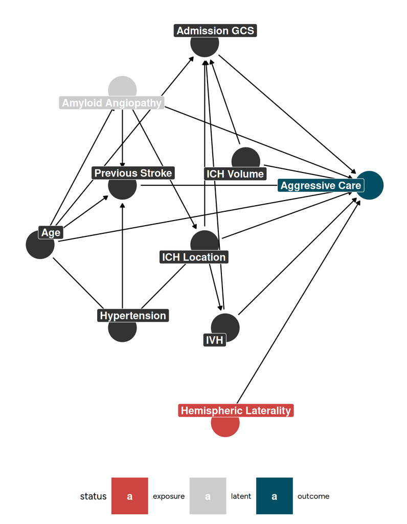

```r
dag_aggressive |>
  tidy_dagitty() |>
  node_status() |>
  ggplot(aes(x = x, y = y, xend = xend, yend = yend)) +
  geom_dag_point(aes(color = status)) +
  geom_dag_edges() +
  geom_dag_label_repel(aes(label = label, fill = status),
    seed = 51,
    color = "white", fontface = "bold", size = 4.5
  ) +
  scale_color_manual(values = status_colors, na.value = "grey20") +
  scale_fill_manual(values = status_colors, na.value = "grey20")
```

#### DAG-Implied Adjustment Sets

Since there is no variable that affects `hemispheric_laterality` in the DAG, the minimally sufficient adjustment set does not include any variables for the estimand of interest (total effect of `hemispheric_laterality`).

```r
adjustmentSets(
  dag_aggressive,
  type = "minimal",
  effect = "total",
  max.results = Inf
)
```

```
 {}
```

```r
adjustmentSets(
  dag_aggressive,
  type = "canonical",
  effect = "total",
  max.results = Inf
)
```

```
{ age, gcs_baseline, hypertension, ich_location, ich_volume, ivh,
  stroke }
```